# False-Discovery Rates with the Hedenfalk et al. (2001) Microarray Data

Sara Hussin

November 20, 2024

# 1 Setup

Ensure that the following packages are installed: `knitr`, `FDRestimation`, `lemon`, `BiocManager`, and `qvalue`. Note that `qvalue` must be installed directly via `BiocManager`.

```r
if (!require("qvalue", quietly = TRUE))
    BiocManager::install('qvalue')
```

# 2 Introduction to this Project

The goal of this project is to provide hands-on experience in performing genome-wide analyses of differentially expressed genes (DEGs) using permutation distributions and the False Discovery Rate (FDR).

In this project, we reproduce key results from [Storey and Tibshirani (2003)](https://www.pnas.org/content/100/16/9440), leveraging the `FDRestimation` package by Megan H. Murray and Jeffrey D. Blume, as described in [FDRestimation: Flexible False Discovery Rate Computation in R](https://f1000research.com/articles/10-441/v2). Instead of calculating permutation $t$-tests directly, we utilize precomputed permutation-$t$ statistics from John Storey’s `qvalue` package for efficiency.

The project involves replicating several of Storey and Tibshirani’s findings and exploring the impact of different statistical assumptions. A primary objective is to demonstrate that the permutation $p$-value approach, as used by Storey and Tibshirani, detects more significant genes compared to the parametric $p$-values obtained from the base R `t.test` function. The reliance on parametric $p$-values not only violates underlying assumptions but also proves less effective in identifying differential expression in this dataset.

# 3 Download and Load Hedenfalk (2001) Microarray Gene Expression Data

## 3.1 Background

As usual for a decades-old paper, it is non-trivial to find the microarray data that [Storey and Tibshirani (2003)](https://www.pnas.org/content/100/16/9440) analyzed from [Hedenfalk *et al.* (2001). Gene-Expression Profiles in Hereditary Breast Cancer. *N Engl J Med 2001* **344**:539-548](https://www.nejm.org/doi/full/10.1056/NEJM200102223440801).

## 3.2 Code

**Note that the data used in this analysis have already been preprocessed in accordance with Storey and Tibshirani’s methods. Specifically, any gene with an expression ratio $\ge 20$ in any of the three original groups has been removed. Additionally, the data have been log-transformed and standardized, with each numeric column centered to its mean and scaled by its standard deviation, following recommendations by Efron and Tibshirani for this dataset.**

```r
load("~/Desktop/hedenfalk_log_scaled.RData")
```

# 4 Compute *t*-Statistics and Their Parametric *p*-values for this Data

## 4.1 Background

The base R function `t.test` computes, by default, Welch’s Approximate $t$-test for two groups with unequal variances, as this is recommended in general practice.

## 4.2 Code

```r
hedenfalk_log_scaled$t   <- apply(hedenfalk_log_scaled[,4:18],1,function(x)t.test(unlist(x[1:7]),unlist(x[8:15]))$statistic)
hedenfalk_log_scaled$t.p <- apply(hedenfalk_log_scaled[,4:18],1,function(x)t.test(unlist(x[1:7]),unlist(x[8:15]))$p.value)
```

# 5 Compute Permutation *p*-values for *t*-Statistics

## 5.1 Background

The `perm` library is a valuable tool for computing permutation tests and $p$-values for various statistics. To streamline the process and ensure comparability with the results of Storey and Tibshirani (2003), we will utilize precomputed permutation $t$-statistics provided in John Storey’s `qvalue` package.

## 5.2 Code

```r
library(qvalue)
data(hedenfalk)
numperms <- 3171*100
hedenfalk_log_scaled$t_perm.p <- sapply(hedenfalk_log_scaled$t,function(x)sum(abs(as.vector(hedenfalk$stat0)) >= abs(x))/numperms)
```

# 6 Compute Wilcoxon Statistics to compare the BRCA1 and BRCA2 groups to compare power against $t$-statistics

## 6.1 Background

Efron and Tibshirani analyzed the Hedenfalk data using the Wilcoxon statistic, which represents the sum of ranks for one of the groups, compared against a permutation distribution (equivalent to the Mann-Whitney test but employing a different statistic). To enable comparison of results, particularly with False Discovery Rates (FDR), we will also compute the Wilcoxon statistics and their corresponding $p$-values.

Fortunately, the `wilcox.test` function has the same interface as `t.test`, making it straightforward to adapt existing code to perform this alternative test. With functional code for the $t$-test in place, implementing the Wilcoxon test requires only minimal modification.

## 6.2 Code

```r
hedenfalk_log_scaled$wilcox.p <- apply(hedenfalk_log_scaled[,4:18],1,function(x)wilcox.test(unlist(x[1:7]),unlist(x[8:15]))$p.value)
```

# 7 Compute False Discovery Rates for Different $p$-values and Find More or Less Numbers of Differentially Expressed Genes Under Different Methods of Computing $p$-values

## 7.1 Background

In Murray and Blume’s `FDRestimation` package described in [FDRestimation: Flexible False Discovery Rate Computation in R](https://f1000research.com/articles/10-441/v2) and its article in F1000, the authors invert Benjamini and Hochberg’s FDR method to compute individual FDRs for each $p$-value. The FDR-values that they recommend using to filter for interesting genes are contained in the `fdrs` element of the return object of the `p.val` function.

## 7.2 Code

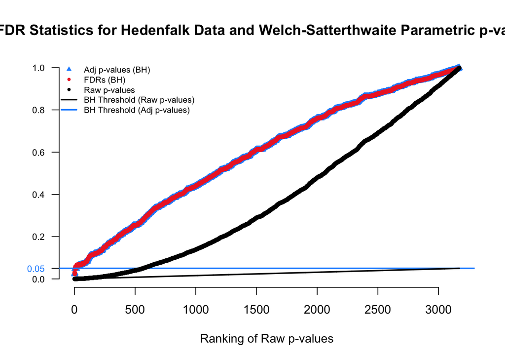

```r
library(FDRestimation)
p.fdr.obj <- p.fdr(p=hedenfalk_log_scaled$t.p)
hedenfalk_log_scaled$t.p.fdrs <- p.fdr.obj$fdrs
plot(p.fdr.obj, main="FDR Statistics for Hedenfalk Data and Welch-Satterthwaite Parametric p-values")
```

Now, we compute FDRs for the permutation-based $p$-values and for the Wilcoxon-statistic $p$-values.

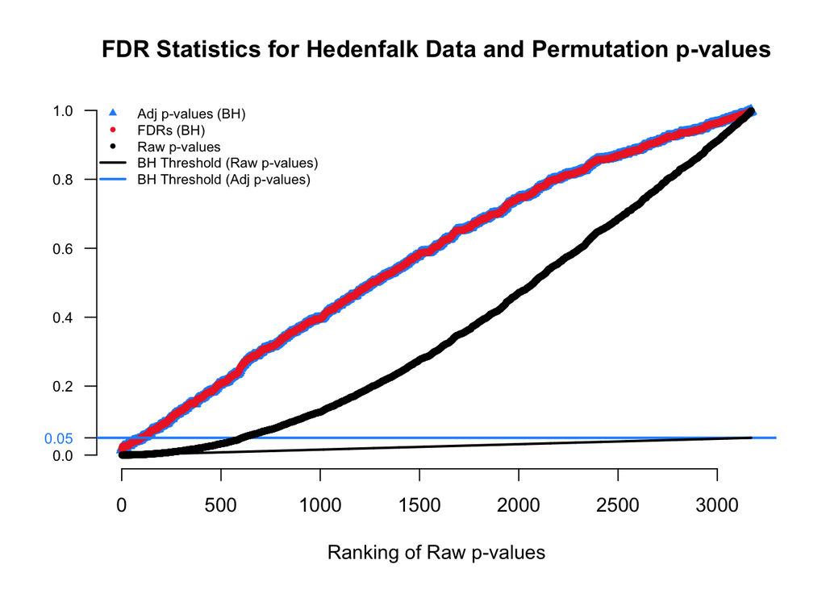

```r
p.fdr.obj <- p.fdr(p=hedenfalk_log_scaled$t_perm.p)
hedenfalk_log_scaled$t_perm.p.fdrs <- p.fdr.obj$fdrs
plot(p.fdr.obj, main="FDR Statistics for Hedenfalk Data and Permutation p-values")
```

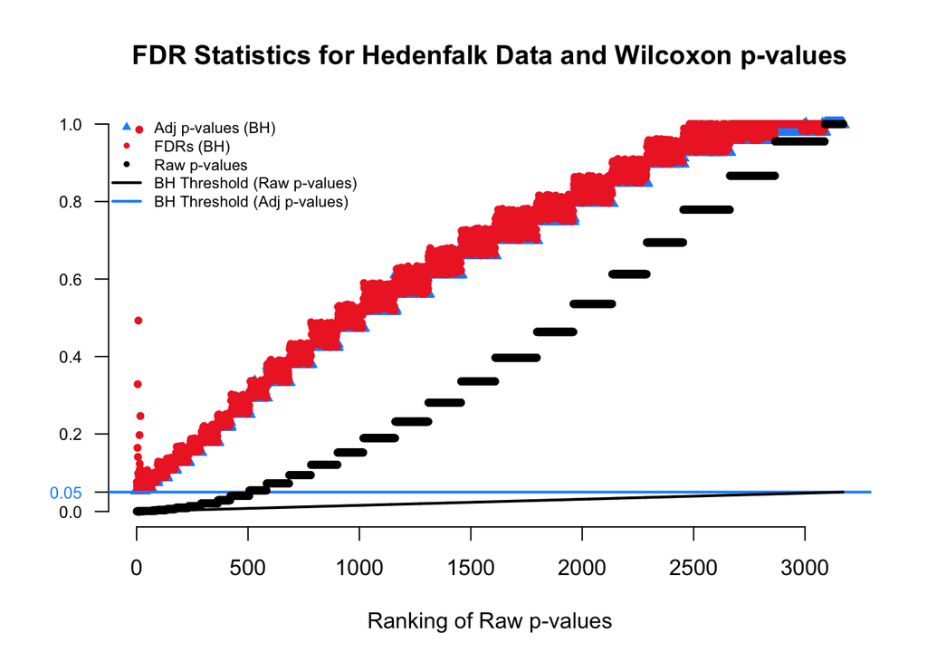

```r
p.fdr.obj <- p.fdr(p=hedenfalk_log_scaled$wilcox.p)
hedenfalk_log_scaled$wilcox.p.fdrs <- p.fdr.obj$fdrs
plot(p.fdr.obj, main="FDR Statistics for Hedenfalk Data and Wilcoxon p-values")
```

# 8 Compare Numbers of Interesting Genes by FDR for Different $p$-values

How many genes are significant using parametric *p*-values and an FDR of 5%? Let’s find out.

```r
answer <- sum(hedenfalk_log_scaled$t.p.fdrs <= 0.05)
print(answer)
```

```
## [1] 6
```

Now let’s check results with the Wilcoxon statistic:

```r
answer <- sum(hedenfalk_log_scaled$wilcox.p.fdrs <= 0.05)
print(answer)
```

```
## [1] 0
```

Do we get more or fewer genes at this FDR threshold with permutation *p*-values than with the other two?

```r
answer <- sum(hedenfalk_log_scaled$t_perm.p.fdrs <= 0.05)
print(answer)
```

```
## [1] 97
```

Is this the same as, more or fewer than the number found significant by Storey and Tibshirani at FDR 5%? Check page 9443, second column, second from last paragraph to see how many DEGs they found. What could explain the difference we are observing? Storey and Tibshirani took into account an estimate of “null” genes – they estimated about 0.67. We will provide this number in the `set.pi0` argument to `p.fdr`:

```r
p.fdr.obj <- p.fdr(p=hedenfalk_log_scaled$t_perm.p,set.pi0 = 0.67)
answer <- sum(p.fdr.obj$fdrs <= 0.05)
print(answer)
```

```
## [1] 165
```

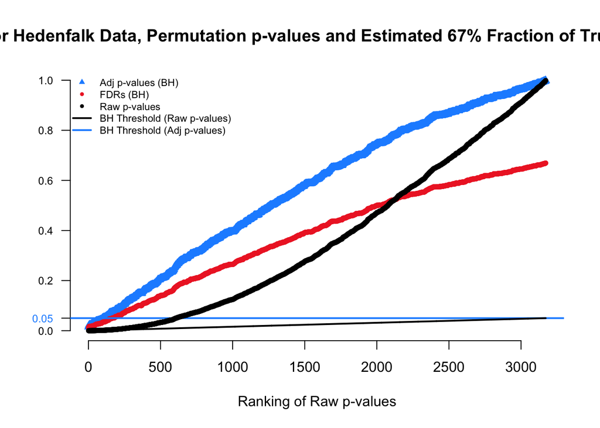

```r
plot(p.fdr.obj, main="FDR Statistics for Hedenfalk Data, Permutation p-values and Estimated 67% Fraction of Truly Null-Effect Genes")
```

# 9 Printing the “Interesting” Genes Sorted by their FDRs

We will print the first three columns of `hedenfalk_log_scaled` for the rows that have permutation-$t$ FDR less than or equal to set 0.02 (computed with estimated null proportion (NDEG fraction) of 67%)..

```r
p.fdr.obj <- p.fdr(p=hedenfalk_log_scaled$t_perm.p,set.pi0 = 0.67)
hedenfalk_log_scaled$t_perm.p.fdrs.67 <- p.fdr.obj$fdrs
answer <- hedenfalk_log_scaled[hedenfalk_log_scaled$t_perm.p.fdrs.67 <= 0.02, 1:3]
print(answer)
```

```
##      Clone_ID   UniGene
## 225    183200  Hs.73875
## 266    810057   Hs.1139
## 429    950682  Hs.99910
## 483    897781 Hs.242463
## 551    712604 Hs.239138
## 584    784830  Hs.82043
## 592    841617 Hs.125078
## 668    812227 Hs.170222
## 799    564803    Hs.239
## 853    949932  Hs.74497
## 873     75009 Hs.155227
## 948     81331 Hs.153179
## 952    566887   Hs.8123
## 986    841641  Hs.82932
```

[output cut: 63 more lines]

# 10 Conclusions

This project provided valuable experience in conducting $t$-tests in R using the `t.test()` and `wilcox.test()` functions. We were also introduced to powerful libraries, such as `qvalue` and `FDRestimation`, which will be instrumental for future statistical analyses. Notably, this was our first experience working with microarray data and identifying differentially expressed genes (DEGs). Successfully applying these methods independently was a significant achievement.